# STA 563 Final Project

Sheikh Arafat

11/14/2021

### Maternal Determinants of Birth Weight in the US: An Application of Multiple Regression

#### Introduction

**As the time and technology progress, people realized that birth weight is actually a important factor for new born babies mortality. In 2015, within 20.5 millon newborns, approximately 14.6% of all babies globally suffer from low weight. And low birth weight is a sign of intrauterine malnutrition. There are different factors which can affect the birth weights. These different factor include but not limited to: 1. Psychological stress, 2. Social disadvantage, 3. Consumption of alcohol and cigarette, 4. Environmental factors and 5. Maternal factors.** **In this project, our goal is to identify important maternal factors which affect birth weight positively or negatively via methods of multiple linear regression.**

```r
#read the final data set
data_f<-read.csv("C:\\Users\\sheik\\OneDrive\\Desktop\\Regression_Multiple\\births_75.csv")
```

```r
#check the summary of the data
summary(data_f)
```

```
##    MotherAge       MotherBMI     MotherPrePWeight   WeightGain
##  Min.   :14.00   Min.   :14.10   Min.   : 80      Min.   : 0.00
##  1st Qu.:25.00   1st Qu.:22.70   1st Qu.:130      1st Qu.:20.00
##  Median :29.00   Median :26.20   Median :152      Median :29.00
##  Mean   :29.29   Mean   :28.91   Mean   :175      Mean   :31.11
##  3rd Qu.:34.00   3rd Qu.:31.60   3rd Qu.:185      3rd Qu.:39.00
##  Max.   :50.00   Max.   :99.90   Max.   :999      Max.   :99.00
##   Cigarette          BirthWeight
##  Length:7500        Min.   : 250
##  Class :character   1st Qu.:2948
##  Mode  :character   Median :3289
##                     Mean   :3255
##                     3rd Qu.:3620
##                     Max.   :9999
```

```r
#check the catagories of the qualitative variable
table(data_f$Cigarette)
```

```
##
##    N    U    Y
## 7059   29  412
```

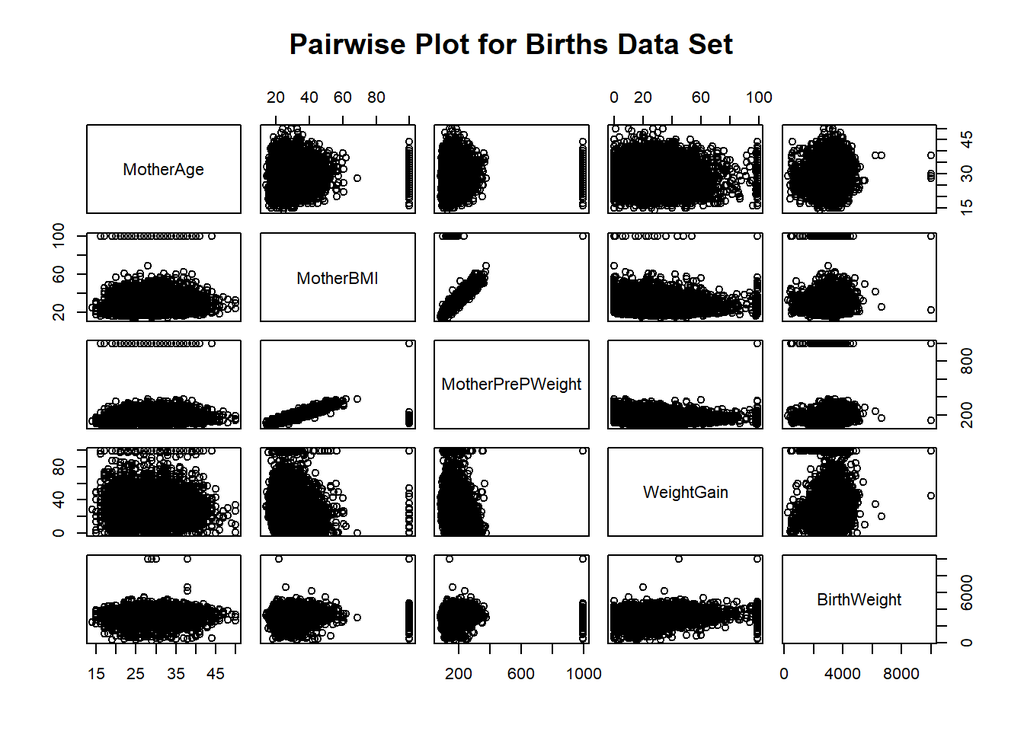

```r
#pairs scatter plots
pairs(data_f[,c(1:4,6)],main='Pairwise Plot for Births Data Set')
```

We have sketched a pairwise plot for the births data set and tried to detect the possible association within the variables. We have observed that almost all the variables are showing a scatter pattern instead of any specific pattern except the Mother’s BMI and Mother’s Prepregnancy Weight. Figure 1 exhibits a positive association between these two predictors.

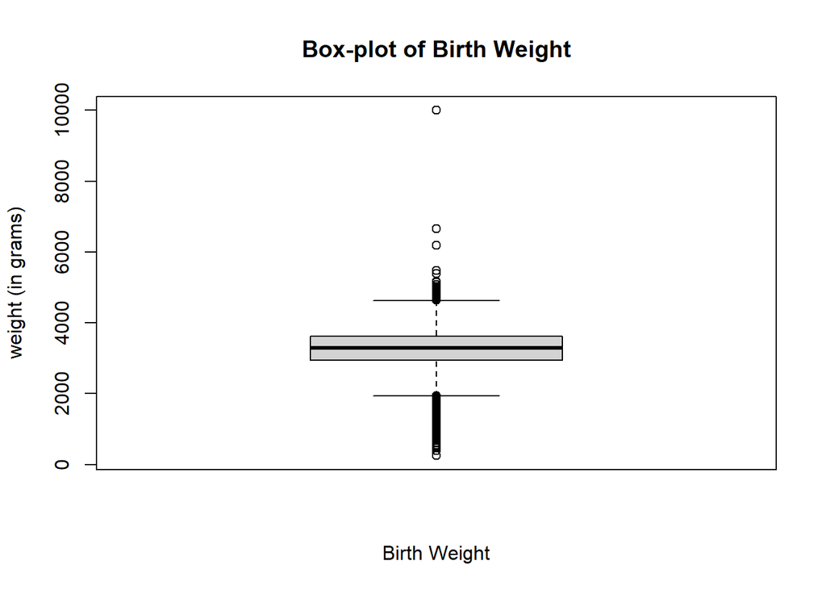

```r
#cleanning the outliers of the data

#check whether outlier exist or not
boxplot(data_f$BirthWeight,main='Box-plot of Birth Weight',ylab='weight (in grams)',xlab='Birth Weight')
```

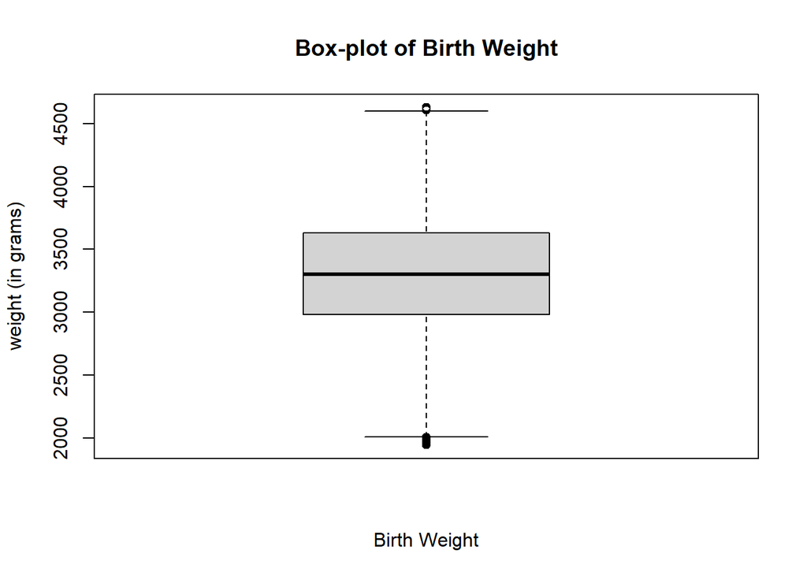

```r
#calculate the IQR
idq_bw<-IQR(data_f$BirthWeight)

#Calculate the quartiles
Q1 <- quantile(data_f$BirthWeight, probs=c(.25, .75), na.rm = FALSE)

#final data set without outliers
data_f1<- subset(data_f, data_f$BirthWeight > (Q1[1] - 1.5*idq_bw) & data_f$BirthWeight < (Q1[2]+1.5*idq_bw))

#boxplot of the outlier removed data set
boxplot(data_f1$BirthWeight,main='Box-plot of Birth Weight',ylab='weight (in grams)',xlab='Birth Weight')
```

To check whether the data set has any outliers or not. We have created a box-plot of the response variable and observed that a lot of outliers exist in the data set (Ref. Figure 2). The values of birth weight which are below and above the 1.5IQR of the first and third quartile respectively are removed from the data set.

After preparing the data set, we fit the multiple regression model. We have a qualitative predictor variable with three categories and introduce two dummy or indicator variables in our model. We define the dummy or indicator variables as follows: The indivator Variable in our project is: $Ciagerette_Y$ : whether the number smoke before or during the pregnncy.

```r
#fit the regression model

#factor the categorical variable type
data_f1$Cigarette.f<-factor(data_f1$Cigarette)

#fit the model
model_fit1<-lm(BirthWeight~ MotherAge+MotherBMI+MotherPrePWeight+WeightGain+Cigarette.f,data=data_f1)

#check the summary of the fitted model
summary(model_fit1)
```

```
##
## Call:
## lm(formula = BirthWeight ~ MotherAge + MotherBMI + MotherPrePWeight +
##     WeightGain + Cigarette.f, data = data_f1)
##
## Residuals:
##      Min       1Q   Median       3Q      Max
## -1529.09  -316.42     9.75   321.37  1383.16
##
## Coefficients:
##                   Estimate Std. Error t value Pr(>|t|)
## (Intercept)      3028.8298    35.0219  86.484  < 2e-16 ***
## MotherAge           4.2091     0.9567   4.400 1.10e-05 ***
## MotherBMI           4.5085     1.1719   3.847  0.00012 ***
## MotherPrePWeight   -0.5465     0.1297  -4.214 2.54e-05 ***
## WeightGain          3.9853     0.3448  11.560  < 2e-16 ***
## Cigarette.fU     -297.9971    90.9704  -3.276  0.00106 **
## Cigarette.fY     -195.3089    24.8718  -7.853 4.66e-15 ***
## ---
## Signif. codes:  0 '***' 0.001 '**' 0.01 '*' 0.05 '.' 0.1 ' ' 1
##
## Residual standard error: 478 on 7231 degrees of freedom
## Multiple R-squared:  0.03042,    Adjusted R-squared:  0.02962
## F-statistic: 37.82 on 6 and 7231 DF,  p-value: < 2.2e-16
```

When $Cigarette_Y$:  
$Y_i = \beta_0 + \beta_6 + \beta_1X_1i + \beta_2X_2i + \beta_3X_3i + \beta_4X_4i + \epsilon_i$  
$\hat{Y_i} = 2833.52 + 4.21X_1i + 4.51X_2i - 0.55X_3i + 3.99X_4i$ <br

When $Cigarette_N$:  
$Y_i = \beta_0 + \beta_1X_1i + \beta_2X_2i + \beta_3X_3i + \beta_4X_4i + \epsilon_i$  
$\hat{Y_i} = 3028.83 + 4.21X_1i + 4.51X_2i - 0.55X_3i + 3.99X_4i$

```r
#performing the ANOVA
anova(model_fit1)
```

```
## Analysis of Variance Table
##
## Response: BirthWeight
##                    Df     Sum Sq  Mean Sq  F value    Pr(>F)
## MotherAge           1    4288423  4288423  18.7679 1.496e-05 ***
## MotherBMI           1    1243963  1243963   5.4441   0.01966 *
## MotherPrePWeight    1       1278     1278   0.0056   0.94038
## WeightGain          1   29947478 29947478 131.0622 < 2.2e-16 ***
## Cigarette.f         2   16365446  8182723  35.8109 3.342e-16 ***
## Residuals        7231 1652270245   228498
## ---
## Signif. codes:  0 '***' 0.001 '**' 0.01 '*' 0.05 '.' 0.1 ' ' 1
```

```r
#CI of the coefficients
confint(model_fit1)
```

```
##                         2.5 %       97.5 %
## (Intercept)      2960.1767113 3097.4828488
## MotherAge           2.3336998    6.0845525
## MotherBMI           2.2112740    6.8056566
## MotherPrePWeight   -0.8007546   -0.2922625
## WeightGain          3.3094621    4.6611202
## Cigarette.fU     -476.3256818 -119.6684321
## Cigarette.fY     -244.0649045 -146.5528385
```

Now, to check the usefulness of the model, we have performed the F-test, where we set the hypothesis as $H_0:\beta_1=\beta_2=\beta_3=\beta_4=\beta_5=\beta_6=0$  
$H_1$:At least one $\beta_i$≠0, i = 1, 2,…6

The calculated value of the test statistic is 37.82 on 6 and 7231 degrees of freedom with a p-value of $2.26 × 10−16$. As the p-value is less than any usual level of significance, we have rejected the null hypothesis which implies that the fitted model is useful to estimate the birth weight. After that, we have performed the individual t-test to check the significance of the individual predictors of the fitted model. Similarly, with the F-test, we have observed that all the p-values of the individual ttest provide smaller p-values than the usual level of significance. In addition to this, none of the 95% confidence intervals of the regression coefficients include zero which also implies that the regression coefficients values are different than zero. So, we can conclude that all the considered predictors of the fitted model are significant and required to model the birth weight. Though the fitted model is significant and all the considered predictors are useful, the multiple R-squared of the fitted model is 0.0304. This implies that 3.04% of the total variations in the response variable birth weight are explained by the linear relationship of the considered predictors. The birth weight is not only dependent on the maternal factors but also the social, psychological, demographic, and environmental factors that play a vital role in modeling birth weight. Due to this reason, we are observing low multiple R-squared values.

As our fitted model and all the considered predictors are significant, so now we will perform the model diagnostics.

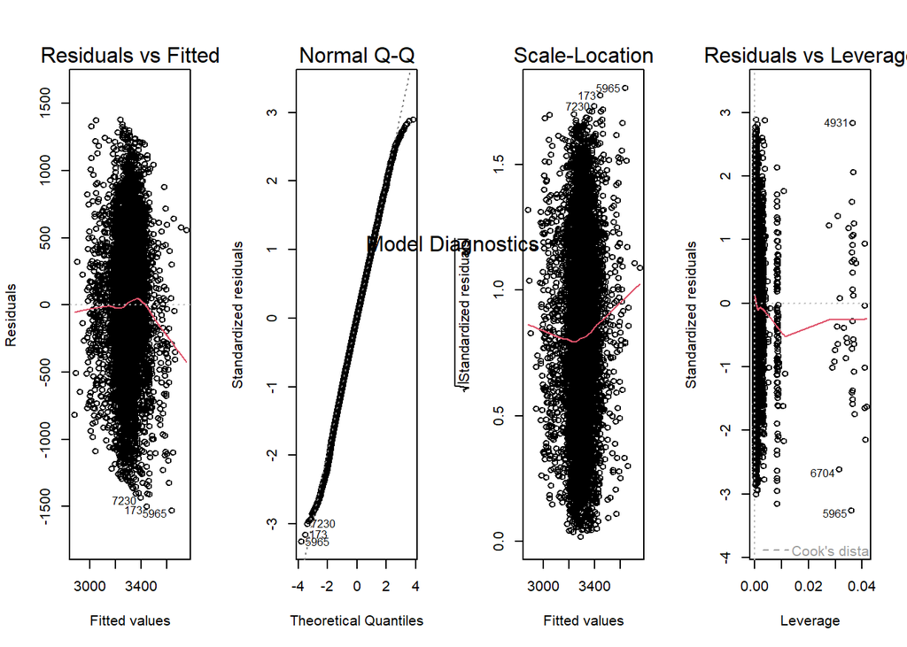

```r
#checking the assumptions of the regression model

#drawing all graphs together
par(mfrow=c(1,4))
plot(model_fit1,cex=0.9)
mtext("Model Diagnostics", side = 1, line = -24, outer = TRUE)
```

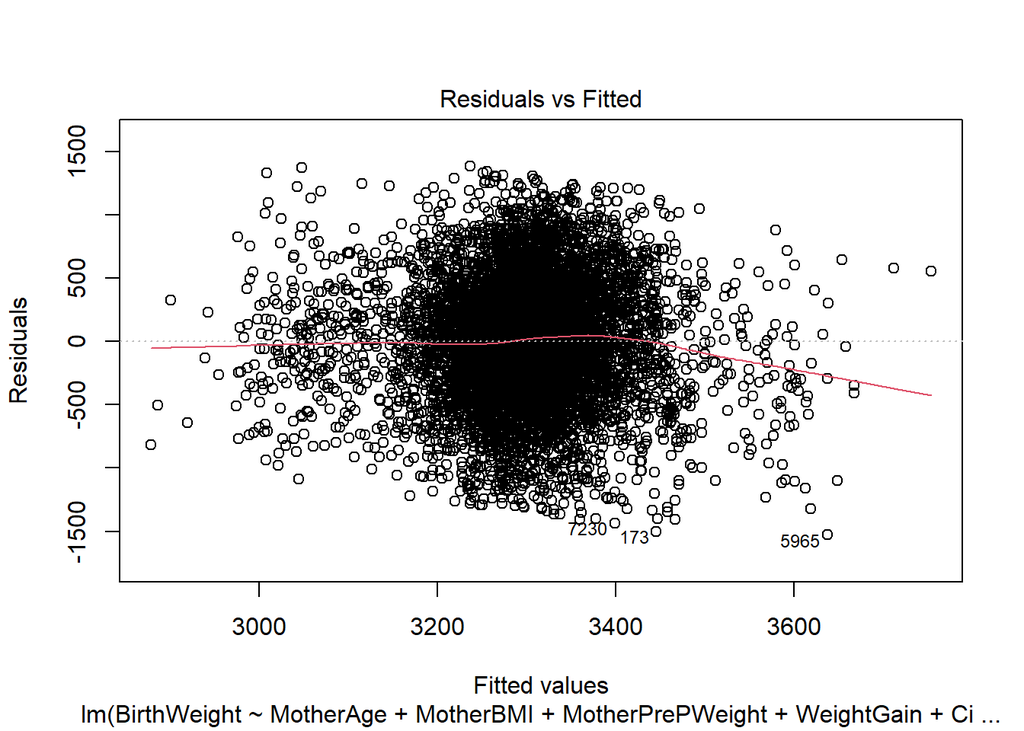

```r
#   Linearity assumption

#checking Linearity assumption by Residual vs Fitted
plot(model_fit1,which=1)
```

Linearity assumption: For checking the linearity assumption of the residuals we have plotted the “Residuals vs Fitted” and observed that the residuals are bouncing randomly around the $e_i = 0$ line, resulting in a roughly flat (horizontal) smoother (dot trend line) (Ref. Figure 3). So, we can conclude that the residuals of the fitted models satisfy the linearity assumption.

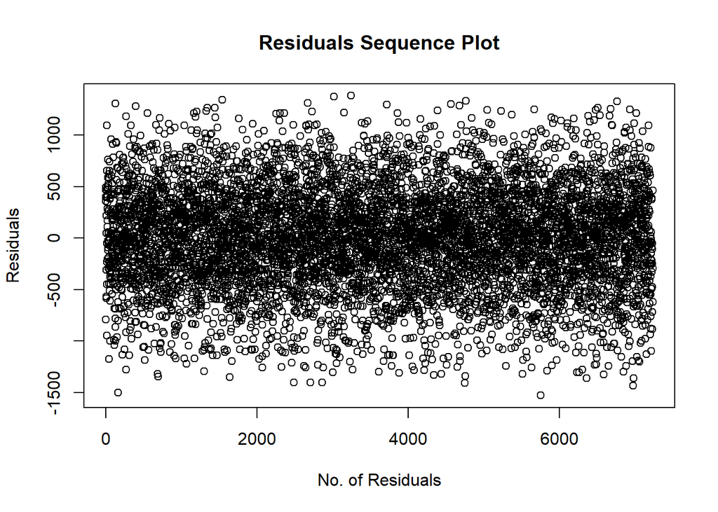

```r
#Independence assumption checking by residuals sequence plot
plot(model_fit1$residuals,main ="Residuals Sequence Plot",xlab = "No. of Residuals",ylab = "Residuals")
```

Independence assumption: We have taken the samples randomly which implies that there is no dependence. In addition to this, We have created the “Residuals Sequence Plot” for checking the independence assumption of the residuals. In that graph, we didn’t observe any pattern (Ref. Figure 4). As a consequence, we can conclude that the residuals of the fitted models are independent.

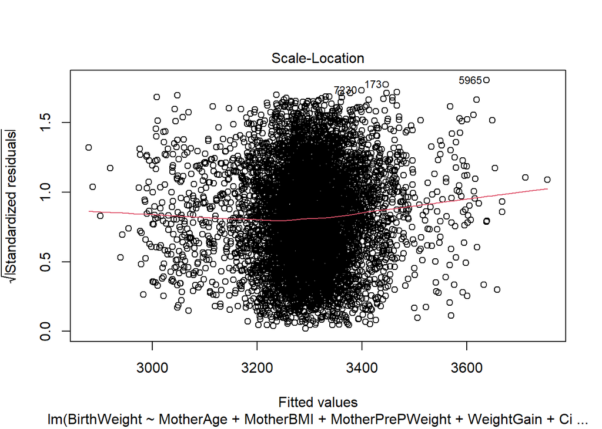

```r
#constant variance assumption

plot(model_fit1, which=3)
```

```r
# Breusch- Pagan Test for constant variance
bptest(model_fit1)
```

```
##
##  studentized Breusch-Pagan test
##
## data:  model_fit1
## BP = 47.276, df = 6, p-value = 1.649e-08
```

Constant Variance assumption: For checking the Constant variance assumption, we have plotted the square root of standardized residuals versus the fitted values. We have observed that the variance in the middle is much smaller than the variance in the right end (Ref. Figure 3). Whereas the condition of the constant variance is the variance should exhibit a horizontal flat line instead of a decreasing or increasing trend. Here, we can suspect that the variance is not constant. So, we are performing a numerical test called the “Breusch- Pagan Test” for verifying our suspect. The hypothesis of this test is: $H_0$:The variance of errors is constant.  
$H_1$:The variance of errors is NOT constant.  
The value of the test statistic is BP=47.276 with a p-value of $1.65 × 10^8$ As the p-value is less than the usual level of significance which is 0.05. Therefore, we are rejecting the null hypothesis. So, we can conclude that the variance of errors is not constant which is similar to our graphical findings.

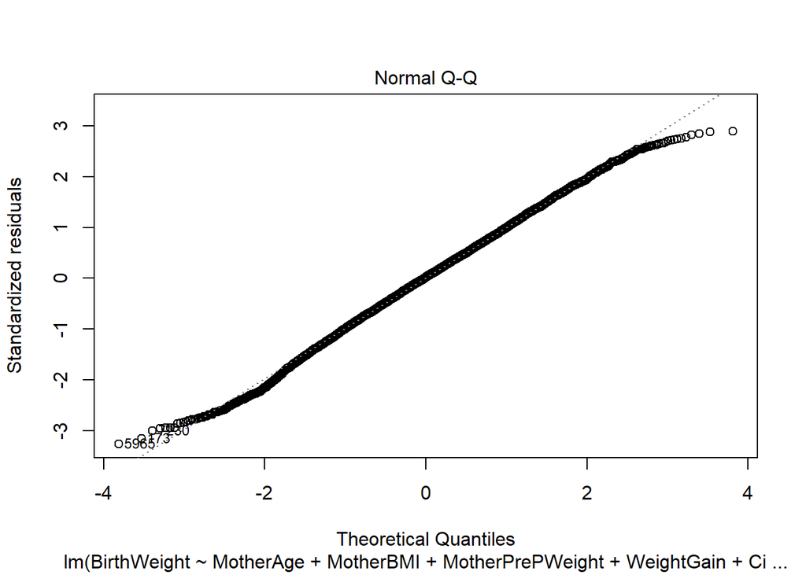

```r
# Normality assumption by Q-Q Plot

plot(model_fit1, which=2) #normal Q-Q Plot
```

```r
#AD test for normality
ad.test(model_fit1$residuals)
```

```
##
##  Anderson-Darling normality test
##
## data:  model_fit1$residuals
## A = 1.397, p-value = 0.001299
```

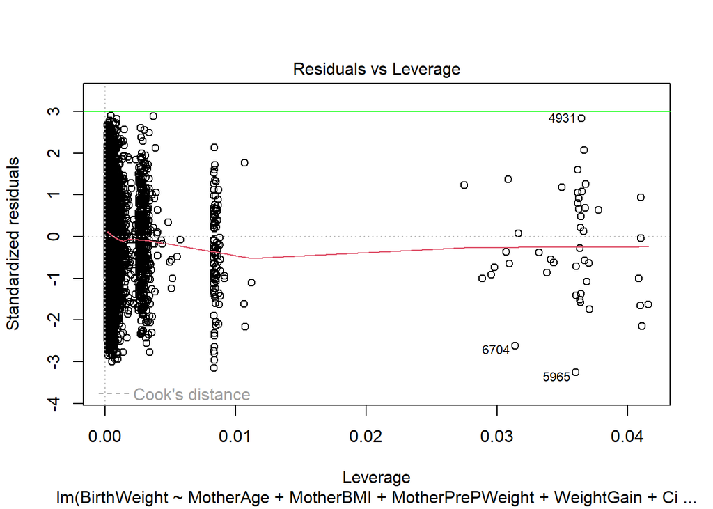

```r
# unusual observations

plot(model_fit1, which=5)
abline(h=3,col="green") #Outliers
```

As we have seen that the model has non-constant variance and the residuals aren’t also normally distributed. We will perform the box-cox transformation to improve the models’ behavior.

The box-cox transformation is strictly designed for a positive response (Y>0). As our response variable is “Birth Weight” which contains all the positive values so that we can apply the box-cox transformation for finding the best fit to the data

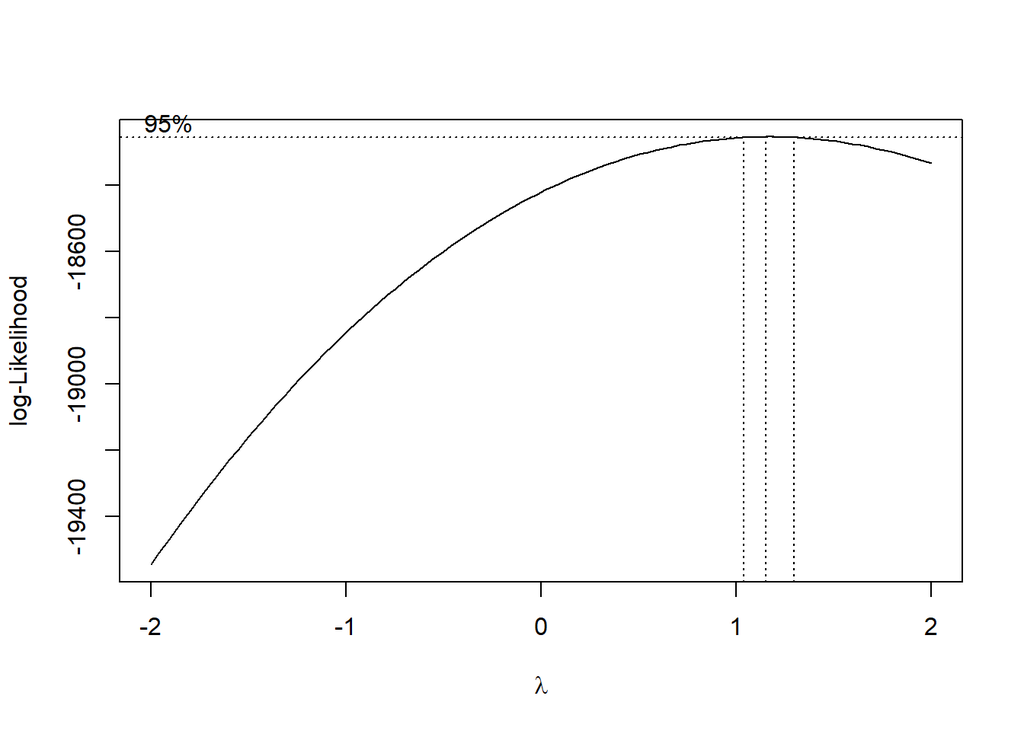

```r
#performing the box-cox transformation

bc<-boxcox(model_fit1)
```

```r
bc$x[which.max(bc$y)]
```

```
## [1] 1.151515
```

In the Box-Cox method, instead of fitting the original Y as the response, we determine a transformed version. For getting the best 𝜆 estimate, we calculate the log-likelihood of the data that makes the log-likelihood maximum. Here, we have found that for 𝜆 = 1.15, we will get the maximum log-likelihood (Ref. Figure 5). We have to consider the nearest value to the optimum and which is 1. So, the box-cox transformation isn’t also providing a better result for this case.

```r
#fit the transformed model
model_fit2<-lm((BirthWeight^2)~ MotherAge+MotherBMI+MotherPrePWeight+WeightGain+Cigarette.f,data=data_f1)

#summary of the transformed model
summary(model_fit2)
```

```
##
## Call:
## lm(formula = (BirthWeight^2) ~ MotherAge + MotherBMI + MotherPrePWeight +
##     WeightGain + Cigarette.f, data = data_f1)
##
## Residuals:
##      Min       1Q   Median       3Q      Max
## -8975530 -2206806  -159853  1985399 10641216
##
## Coefficients:
##                    Estimate Std. Error t value Pr(>|t|)
## (Intercept)       9247182.1   230909.4  40.047  < 2e-16 ***
## MotherAge           29345.7     6307.9   4.652 3.34e-06 ***
## MotherBMI           30937.9     7726.4   4.004 6.29e-05 ***
## MotherPrePWeight    -3638.2      855.1  -4.255 2.12e-05 ***
## WeightGain          26675.9     2273.1  11.735  < 2e-16 ***
## Cigarette.fU     -1783054.7   599794.8  -2.973  0.00296 **
## Cigarette.fY     -1255457.0   163987.2  -7.656 2.17e-14 ***
## ---
## Signif. codes:  0 '***' 0.001 '**' 0.01 '*' 0.05 '.' 0.1 ' ' 1
##
## Residual standard error: 3152000 on 7231 degrees of freedom
## Multiple R-squared:  0.03084,    Adjusted R-squared:  0.03004
## F-statistic: 38.35 on 6 and 7231 DF,  p-value: < 2.2e-16
```

```r
#ANOVA of the transformed model
anova(model_fit2)
```

```
## Analysis of Variance Table
##
## Response: (BirthWeight^2)
##                    Df     Sum Sq    Mean Sq  F value    Pr(>F)
## MotherAge           1 2.0785e+14 2.0785e+14  20.9246 4.857e-06 ***
## MotherBMI           1 7.2028e+13 7.2028e+13   7.2512  0.007102 **
## MotherPrePWeight    1 1.4834e+11 1.4834e+11   0.0149  0.902741
## WeightGain          1 1.3427e+15 1.3427e+15 135.1693 < 2.2e-16 ***
## Cigarette.f         2 6.6320e+14 3.3160e+14  33.3832 3.702e-15 ***
## Residuals        7231 7.1827e+16 9.9332e+12
## ---
## Signif. codes:  0 '***' 0.001 '**' 0.01 '*' 0.05 '.' 0.1 ' ' 1
```

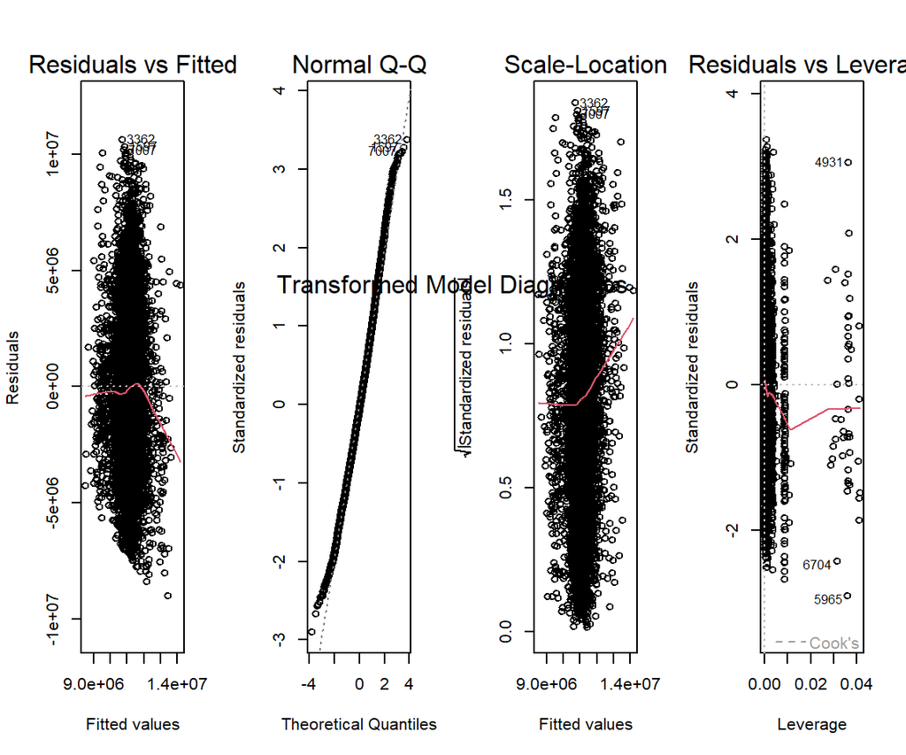

```r
#checking the assumptions of the transformed regression model

#drawing all graphs together
par(mfrow=c(1,4))
plot(model_fit2,cex=0.9)
mtext("Transformed Model Diagnostics", side = 1, line = -24, outer = TRUE)
```

[figure not shown]

```r
## checking whether log transformation is applicable or not

# histogram of the response variable
x <- data_f1$BirthWeight
h<-hist(x,xlab="Birth Weight",
        main="Histogram of Birth Weight with Normal Curve")
xfit<-seq(min(x),max(x),length=40)
yfit<-dnorm(xfit,mean=mean(x),sd=sd(x))
yfit <- yfit*diff(h$mids[1:2])*length(x)
lines(xfit, yfit, col="blue", lwd=2)
```

The histogram of the birth weight shows that the distribution is almost normally distributed so the log transformation will not be an effective one. As a consequence, instead of using the considered assumptions, we will use the original model.

```r
# Fit the best model

# Stepwise regression model by AIC
step.model <- stepAIC(lm(BirthWeight ~  MotherAge+MotherBMI+MotherPrePWeight+WeightGain+Cigarette.f, data = data_f1), direction = "both", k=2)
```

```
## Start:  AIC=89318.73
## BirthWeight ~ MotherAge + MotherBMI + MotherPrePWeight + WeightGain +
##     Cigarette.f
##
##                    Df Sum of Sq        RSS   AIC
## <none>                          1652270245 89319
## - MotherBMI         1   3382108 1655652353 89332
## - MotherPrePWeight  1   4057043 1656327289 89334
## - MotherAge         1   4422910 1656693156 89336
## - Cigarette.f       2  16365446 1668635692 89386
## - WeightGain        1  30533086 1682803332 89449
```

```r
# Stepwise regression model by BIC
n<-length(data_f$BirthWeight)
step.model2 <- stepAIC(lm(BirthWeight ~ MotherAge+MotherBMI+MotherPrePWeight+WeightGain+Cigarette.f, data = data_f1), direction = "both", k=log(n))
```

```
## Start:  AIC=89367.19
## BirthWeight ~ MotherAge + MotherBMI + MotherPrePWeight + WeightGain +
##     Cigarette.f
##
##                    Df Sum of Sq        RSS   AIC
## <none>                          1652270245 89367
## - MotherBMI         1   3382108 1655652353 89373
## - MotherPrePWeight  1   4057043 1656327289 89376
## - MotherAge         1   4422910 1656693156 89378
## - Cigarette.f       2  16365446 1668635692 89421
## - WeightGain        1  30533086 1682803332 89491
```

```r
#checking multicolieanirity

omcdiag(model_fit1)
```

```
##
## Call:
## omcdiag(mod = model_fit1)
##
##
## Overall Multicollinearity Diagnostics
##
##                        MC Results detection
## Determinant |X'X|:         0.1430         0
## Farrar Chi-Square:     14067.9181         1
## Red Indicator:             0.2626         0
## Sum of Lambda Inverse:    16.7279         0
## Theil's Method:            1.7441         1
## Condition Number:         19.2272         0
##
## 1 --> COLLINEARITY is detected by the test
## 0 --> COLLINEARITY is not detected by the test
```

```r
imcdiag(model_fit1)
```

```
##
## Call:
## imcdiag(mod = model_fit1)
##
##
## All Individual Multicollinearity Diagnostics Result
##
##                     VIF    TOL        Wi        Fi Leamer   CVIF Klein  IND1
## MotherAge        1.0063 0.9938    9.0778   11.3489 0.9969 1.0045     0 7e-04
## MotherBMI        5.9333 0.1685 7135.4884 8920.5938 0.4105 5.9228     1 1e-04
## MotherPrePWeight 6.5277 0.1532 7995.2297 9995.4191 0.3914 6.5161     1 1e-04
## WeightGain       1.2467 0.8021  356.8458  446.1189 0.8956 1.2445     1 6e-04
## Cigarette.fU     1.0102 0.9899   14.7034   18.3818 0.9950 1.0084     0 7e-04
## Cigarette.fY     1.0038 0.9962    5.4616    6.8279 0.9981 1.0020     0 7e-04
##                    IND2
## MotherAge        0.0197
## MotherBMI        2.6309
## MotherPrePWeight 2.6795
## WeightGain       0.6262
## Cigarette.fU     0.0318
## Cigarette.fY     0.0119
##
## 1 --> COLLINEARITY is detected by the test
## 0 --> COLLINEARITY is not detected by the test
##
## * all coefficients have significant t-ratios
##
## R-square of y on all x: 0.0304
##
## * use method argument to check which regressors may be the reason of collinearity
## ===================================
```

```r
#calculating VIF
vif(model_fit1)
```

```
##                      GVIF Df GVIF^(1/(2*Df))
## MotherAge        1.006276  1        1.003133
## MotherBMI        5.933275  1        2.435831
## MotherPrePWeight 6.527675  1        2.554932
## WeightGain       1.246713  1        1.116563
## Cigarette.f      1.013516  2        1.003362
```

We have performed the stepwise regression method by considering the forward and backward selection process. We have got the full model as the best model with the AIC of 89318.73 and BIC of 89367.19. As we have seen from the pairwise plot that there is a possible association between the Mother BMI and Mother Pre-Pregnancy Weight, so we have performed the multicollinearity test. The multicollinearity is detected by the Farrar Chi-Square test and Theil’s Method. Therefore, to determine the degree of multicollinearity, we have estimated the variance inflation factor (VIF) and observed that for almost all the predictors the VIF is very close to 1 except Mother BMI and Mother Pre-Pregnancy Weight. The Mother Pre-Pregnancy Weight has the highest VIF which is 6.53.

As a consequence, we will remove this predictor from the model and perform the partial F test to check the performance of the reduced model without the Mother Pre-Pregnancy Weight. We set the hypothesis as $H_0: \beta_3 = 0$(Reduced Model is Prefered)  
$H_1: \beta_3 ≠ 0$(Ful Model is Prefered)  
Where, Full Model:$Y_i = \beta_0+\beta_1X_1i+\beta_2X_2i + \beta_3X_3i + \beta_4X_4i + \beta_5Cigarrette_Ui + \beta_6Cigarette_Yi + \epsilon_i$  
Reduced Model:$Y_i = \beta_0+\beta_1X_1i+\beta_2X_2i + \beta_4X_4i + \beta_5Cigarrette_Ui + \beta_6Cigarette_Yi + \epsilon_i$

```r
########## partial F test

#Fit a model without Mother Pre Pregnency Weight

model_fit4<-lm(BirthWeight~ MotherAge+MotherBMI+WeightGain+Cigarette.f,data=data_f1)
summary(model_fit4)
```

```
##
## Call:
## lm(formula = BirthWeight ~ MotherAge + MotherBMI + WeightGain +
##     Cigarette.f, data = data_f1)
##
## Residuals:
##      Min       1Q   Median       3Q      Max
## -1595.62  -313.78     9.86   321.29  1394.00
##
## Coefficients:
##                Estimate Std. Error t value Pr(>|t|)
## (Intercept)  3084.12472   32.50798  94.873  < 2e-16 ***
## MotherAge       4.07561    0.95729   4.257 2.09e-05 ***
## MotherBMI       0.03532    0.49688   0.071 0.943336
## WeightGain      3.42272    0.31823  10.756  < 2e-16 ***
## Cigarette.fU -318.48076   90.94563  -3.502 0.000465 ***
## Cigarette.fY -195.04545   24.90054  -7.833 5.45e-15 ***
## ---
## Signif. codes:  0 '***' 0.001 '**' 0.01 '*' 0.05 '.' 0.1 ' ' 1
##
## Residual standard error: 478.6 on 7232 degrees of freedom
## Multiple R-squared:  0.02804,    Adjusted R-squared:  0.02737
## F-statistic: 41.73 on 5 and 7232 DF,  p-value: < 2.2e-16
```

```r
#partial F test
anova(model_fit4,model_fit1)
```

```
## Analysis of Variance Table
##
## Model 1: BirthWeight ~ MotherAge + MotherBMI + WeightGain + Cigarette.f
## Model 2: BirthWeight ~ MotherAge + MotherBMI + MotherPrePWeight + WeightGain +
##     Cigarette.f
##   Res.Df        RSS Df Sum of Sq      F    Pr(>F)
## 1   7232 1656327289
## 2   7231 1652270245  1   4057043 17.755 2.543e-05 ***
## ---
## Signif. codes:  0 '***' 0.001 '**' 0.01 '*' 0.05 '.' 0.1 ' ' 1
```

The calculated value of the partial test statistic is 17.76 with 1 degree of freedom and the p-value is $2.54 × 10^{-5}$.As the p-value is less than the level of significance, so we will reject the null hypothesis which implies that the full model with all the predictors will be a better fit for the data rather than that the reduced model without the Mother Pre-Pregnancy Weight.

As we have five significant predictor variables in our model, as a consequence the interaction model will increase complexity and will violate the requirement of a parsimonious model. However, we have performed the stepwise regression model with all the interaction terms and tried to find out the best model. We have observed that the model with interaction term contains more than 20 regression coefficients with an adjusted R-square of 0.06. Though the adjusted Rsquare is quite larger than the without interaction model, the model is no longer parsimonious. Finally, we have decided to use the model without the interaction terms.

```r
##fitting interaction model

full.model <- lm(BirthWeight ~.+MotherAge*MotherBMI*MotherPrePWeight*WeightGain*Cigarette.f, data = data_f1)

#find best interaction model

#step-wise regression by AIC
step.model3<-stepAIC(full.model,direction = "both", k=2)
```

```
## Start:  AIC=89029.39
## BirthWeight ~ MotherAge + MotherBMI + MotherPrePWeight + WeightGain +
##     Cigarette + Cigarette.f + MotherAge * MotherBMI * MotherPrePWeight *
##     WeightGain * Cigarette.f
##
##
## Step:  AIC=89029.39
## BirthWeight ~ MotherAge + MotherBMI + MotherPrePWeight + WeightGain +
##     Cigarette.f + MotherAge:MotherBMI + MotherAge:MotherPrePWeight +
##     MotherBMI:MotherPrePWeight + MotherAge:WeightGain + MotherBMI:WeightGain +
##     MotherPrePWeight:WeightGain + MotherAge:Cigarette.f + MotherBMI:Cigarette.f +
##     MotherPrePWeight:Cigarette.f + WeightGain:Cigarette.f + MotherAge:MotherBMI:MotherPrePWeight +
##     MotherAge:MotherBMI:WeightGain + MotherAge:MotherPrePWeight:WeightGain +
##     MotherBMI:MotherPrePWeight:WeightGain + MotherAge:MotherBMI:Cigarette.f +
##     MotherAge:MotherPrePWeight:Cigarette.f + MotherBMI:MotherPrePWeight:Cigarette.f +
##     MotherAge:WeightGain:Cigarette.f + MotherBMI:WeightGain:Cigarette.f +
##     MotherPrePWeight:WeightGain:Cigarette.f + MotherAge:MotherBMI:MotherPrePWeight:WeightGain +
##     MotherAge:MotherBMI:MotherPrePWeight:Cigarette.f + MotherAge:MotherBMI:WeightGain:Cigarette.f +
##     MotherAge:MotherPrePWeight:WeightGain:Cigarette.f + MotherBMI:MotherPrePWeight:WeightGain:Cigarette.f +
##     MotherAge:MotherBMI:MotherPrePWeight:WeightGain:Cigarette.f
##
##                                                               Df Sum of Sq
## <none>
## - MotherAge:MotherBMI:MotherPrePWeight:WeightGain:Cigarette.f  2   1906072
##                                                                      RSS   AIC
## <none>                                                        1569640505 89029
## - MotherAge:MotherBMI:MotherPrePWeight:WeightGain:Cigarette.f 1571546578 89034
```

```r
#step-wise regression by BIC
step.model4<-stepAIC(full.model,direction = "both", k=log(n))
```

```
## Start:  AIC=89361.68
## BirthWeight ~ MotherAge + MotherBMI + MotherPrePWeight + WeightGain +
##     Cigarette + Cigarette.f + MotherAge * MotherBMI * MotherPrePWeight *
##     WeightGain * Cigarette.f
##
##
## Step:  AIC=89361.68
## BirthWeight ~ MotherAge + MotherBMI + MotherPrePWeight + WeightGain +
##     Cigarette.f + MotherAge:MotherBMI + MotherAge:MotherPrePWeight +
##     MotherBMI:MotherPrePWeight + MotherAge:WeightGain + MotherBMI:WeightGain +
##     MotherPrePWeight:WeightGain + MotherAge:Cigarette.f + MotherBMI:Cigarette.f +
##     MotherPrePWeight:Cigarette.f + WeightGain:Cigarette.f + MotherAge:MotherBMI:MotherPrePWeight +
##     MotherAge:MotherBMI:WeightGain + MotherAge:MotherPrePWeight:WeightGain +
##     MotherBMI:MotherPrePWeight:WeightGain + MotherAge:MotherBMI:Cigarette.f +
##     MotherAge:MotherPrePWeight:Cigarette.f + MotherBMI:MotherPrePWeight:Cigarette.f +
##     MotherAge:WeightGain:Cigarette.f + MotherBMI:WeightGain:Cigarette.f +
##     MotherPrePWeight:WeightGain:Cigarette.f + MotherAge:MotherBMI:MotherPrePWeight:WeightGain +
##     MotherAge:MotherBMI:MotherPrePWeight:Cigarette.f + MotherAge:MotherBMI:WeightGain:Cigarette.f +
##     MotherAge:MotherPrePWeight:WeightGain:Cigarette.f + MotherBMI:MotherPrePWeight:WeightGain:Cigarette.f +
##     MotherAge:MotherBMI:MotherPrePWeight:WeightGain:Cigarette.f
##
##                                                               Df Sum of Sq
## - MotherAge:MotherBMI:MotherPrePWeight:WeightGain:Cigarette.f  2   1906072
## <none>
##                                                                      RSS   AIC
## - MotherAge:MotherBMI:MotherPrePWeight:WeightGain:Cigarette.f 1571546578 89353
## <none>                                                        1569640505 89362
##
## Step:  AIC=89352.62
## BirthWeight ~ MotherAge + MotherBMI + MotherPrePWeight + WeightGain +
##     Cigarette.f + MotherAge:MotherBMI + MotherAge:MotherPrePWeight +
##     MotherBMI:MotherPrePWeight + MotherAge:WeightGain + MotherBMI:WeightGain +
##     MotherPrePWeight:WeightGain + MotherAge:Cigarette.f + MotherBMI:Cigarette.f +
##     MotherPrePWeight:Cigarette.f + WeightGain:Cigarette.f + MotherAge:MotherBMI:MotherPrePWeight +
##     MotherAge:MotherBMI:WeightGain + MotherAge:MotherPrePWeight:WeightGain +
##     MotherBMI:MotherPrePWeight:WeightGain + MotherAge:MotherBMI:Cigarette.f +
##     MotherAge:MotherPrePWeight:Cigarette.f + MotherBMI:MotherPrePWeight:Cigarette.f +
##     MotherAge:WeightGain:Cigarette.f + MotherBMI:WeightGain:Cigarette.f +
##     MotherPrePWeight:WeightGain:Cigarette.f + MotherAge:MotherBMI:MotherPrePWeight:WeightGain +
##     MotherAge:MotherBMI:MotherPrePWeight:Cigarette.f + MotherAge:MotherBMI:WeightGain:Cigarette.f +
```

[output cut: 342 more lines]

```
##     MotherBMI:MotherPrePWeight + MotherAge:WeightGain + MotherBMI:WeightGain +
##     MotherPrePWeight:WeightGain + MotherAge:MotherBMI:MotherPrePWeight +
##     MotherAge:MotherPrePWeight:WeightGain + MotherBMI:MotherPrePWeight:WeightGain
##
##                                         Df Sum of Sq        RSS   AIC
## <none>                                               1585528366 89149
## - MotherAge:MotherPrePWeight:WeightGain  1   2538151 1588066518 89152
## + MotherAge:MotherBMI:WeightGain         1    838388 1584689978 89154
## - MotherAge:MotherBMI:MotherPrePWeight   1   3151172 1588679539 89155
## + MotherAge:Cigarette.f                  2   1506426 1584021940 89160
## + MotherBMI:Cigarette.f                  2    692335 1584836032 89164
## + MotherPrePWeight:Cigarette.f           2    641082 1584887284 89164
## + WeightGain:Cigarette.f                 2    331581 1585196785 89165
## - MotherBMI:MotherPrePWeight:WeightGain  1   5916674 1591445040 89167
## - Cigarette.f                            2  18200510 1603728876 89214
```

#### Conclusion

**Finally, from the analysis results, we can see that all predictors that we already choosed are significant during the linear regression analysis process. We can see that mother’s hieght and weight has effect on newborn baby birth weight, and weight gain is exceptional importantly related to newborn baby birth weight. And cigarrete is sure having negative effect on newborn babies birthweight. We can conclude that, mother’s hieght and weight can affect birth weight, but mother’s weight gain and whether or not smoke cigarrete are vitally important on nultrition gain of baby and will be reflected on difference of birth weight.**